# Series de Tiempo

Silvia María Ojeda

Sergio Martín Buzzi

21 de septiembre de 2021

# Temas

> 1. Retardos y diferencias
> 2. Creación de un objeto ts
> 3. Carga de una base de datos
> 4. Simulación de un ruido blanco
> 5. Función de autocorrelación simple muestral
> 6. Simulación de un proceso MA(1)
> 7. Simulación de un proceso MA(2)

# Retardos y diferencias

## Retardos 1 (lag)

Simulamos la serie e

```r
# unimos la serie original y su retardo
cbind(e,lag(e))
```

```
     e
[1,] 1 1
[2,] 2 2
[3,] 3 3
[4,] 4 4
[5,] 5 5
```

Si e va de 1 a 5 lag va de 1 a 4, el primero seria faltante y luego los otros de 1 a 4, esto es lo que esperaria. Pero no es lo que obtengo.

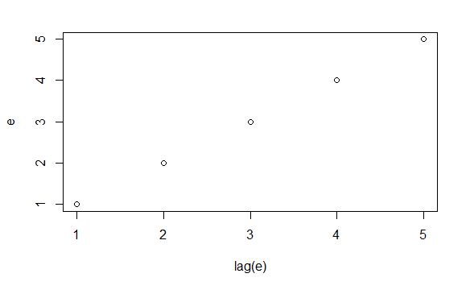

Obtenemos esto y no es lo que quiero en un grafico de la serie contra sus retardos. La funcion lag no hace exactamente lo que se espera.

no es lo esperado!

## Retardos 2 (zlag)

Otra opcion es biblioteca TSA

```r
zlag(e, d=1)
```

```
[1] NA  1  2  3  4
```

Esto es lo que intuitivamente se esperaria. Una mejor opcion.

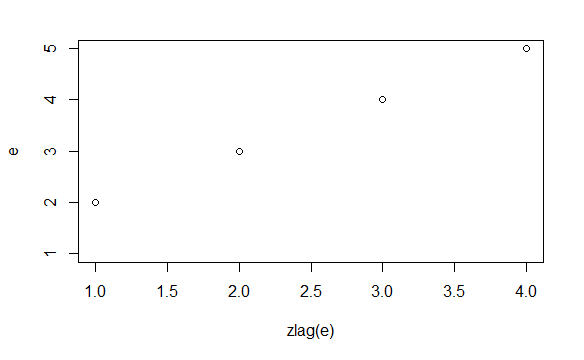

Este gráfico si es correcto.

## Retardos 3 (embed)

```r
embed(e,4)#
```

```
     [,1] [,2] [,3] [,4]
[1,]    4    3    2    1
[2,]    5    4    3    2
```

La función embed permite tomar retardo y la vez eliminar las filas en la que se generan faltantes.

Se recorto la fila que tiene faltante para el lag, la primera fila que antes tenia el NA la elimina.

Cuando se toma lag se pierde un dato.

Veo el retardo de X1,X2,…,Xk.

embed(e,4) Veo 4 lags primer columna, serie y luego los tres primeros retardos.

```r
embed(e,2)
```

```
     [,1] [,2]
[1,]    2    1
[2,]    3    2
[3,]    4    3
[4,]    5    4
```

También es lo que esperábamos.

# Diferencia 1 (usando diff)

```r
cbind(e, diff(e)) # no funciona del todo bien
```

```
number of rows of result is not a multiple of vector length (arg 2)
```

```
     e
[1,] 1 1
[2,] 2 1
[3,] 3 1
[4,] 4 1
[5,] 5 1
```

dif(e), es lo que yo espero, es la diferencia entre ellos, 4 numeros. Esta perfecto.

Pero cuando hago el cbind() me agrega un 1 mas, porque me falta el dato faltante para que quede al principio.

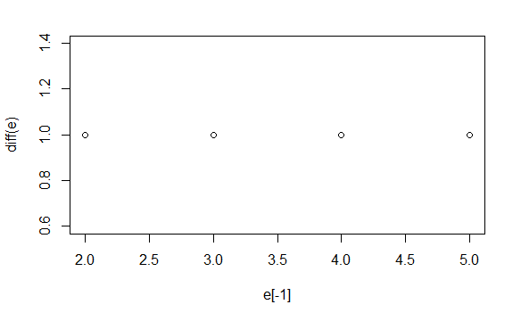

Vemos que la diferencia entre los valores de la serie es siempre la misma.

# Diferencia 2 (usando embed)

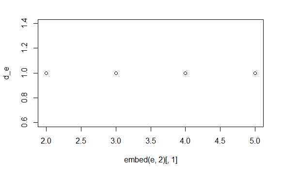

El recomienda como uso practico el zlag. Y tener en cuenta que para las diferencias hay que dropiar uno.

# Creación de un objeto ts

Dada una serie ¿Cómo la definimos como serie de tiempo?

```r
ts_e
```

```
     Qtr1 Qtr2 Qtr3 Qtr4
1995         1    2    3
1996    4    5    6    7
1997    8    9   10   11
1998   12   13   14   15
1999   16   17   18   19
2000   20
```

# Carga de una base de datos

```r
# install.packages("readxl")
library(readxl)
```

```r
length(diff(GDP_ts))
```

```
[1] 204
```

La tasa de crecimiento
$$tc(x)= ln(x_t)-ln(x_{t-1}) = \frac{y_{t}-y_{t-1}}{y_{t-1}}$$
Tremenda forma de poner formulas!!!

# Simulación de un ruido blanco

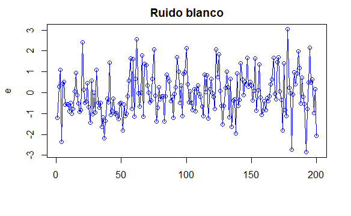

- rnorm genera variables independietnes por lo tanto se cumple la tercera condicion de no correlacionados, pq independencia implica no correlacion.

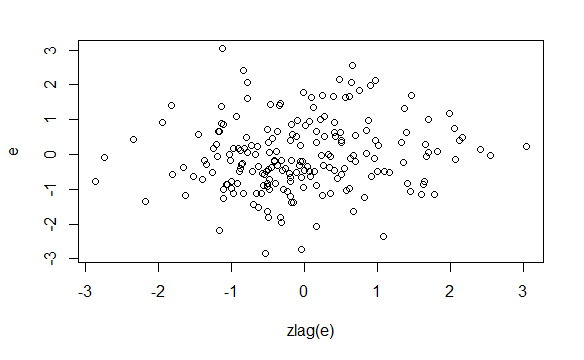

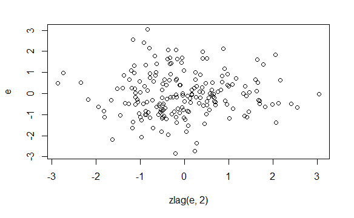

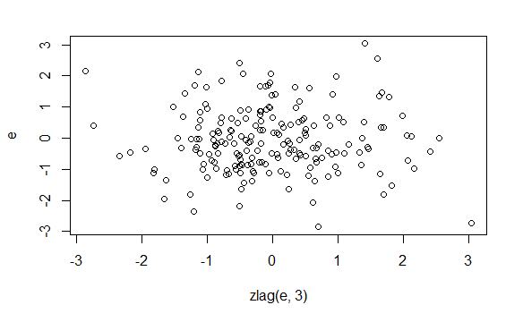

```r
plot(zlag(e), e) # grafico de serie contra su primer retardo
plot(zlag(e,2), e) # graficos con otros retardos

plot(zlag(e,3), e)
```

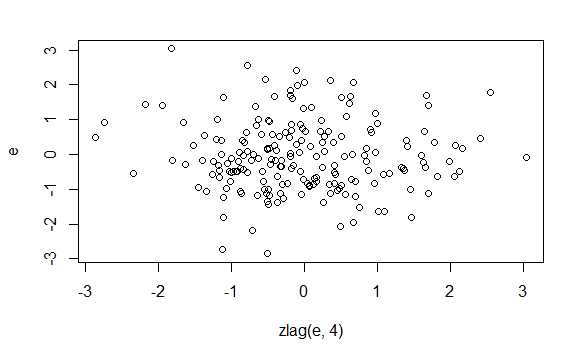

```r
plot(zlag(e,4), e)
```

Es lo esperado.

De que sirve ver estos graficos?. Sirve para ver correlaciones. Anticipo de cual es la funcion de orden para un AR.

# Función de autocorrelación simple muestral

Podemos construir artesanalmente la FAS muestral de orden uno. En el libro de Leiva se puede ver la sección 1.3 sobre la estimación de las características de una serie de tiempo estacionaria. La estimación de las autocorrelaciones está desarrollada en la página 42.

$$\hat{\rho_k} = \frac{\hat{\gamma_k}}{\hat{\gamma_0}} = \frac{\sum_{i=1}^{n-k} (X_t - \bar{X_n})(X_{t+k} - \bar{X_n}) }{\sum_{i=1}^{n} (X_t - \bar{X_n})^2}$$
para $k = 0, , , …, (n-1) $

Entonces la FAS muestral de orden 1 es:

$$\hat{\rho_1} = \frac{\hat{\gamma_1}}{\hat{\gamma_0}} = \frac{\sum_{i=1}^{n-1} (X_t - \bar{X_n})(X_{t-1} - \bar{X_n}) }{\sum_{i=1}^{n} (X_t - \bar{X_n})^2}$$
Pone menos k en vez de mas k porque correlacion es bidireccional, puedo mover el indice tranquilamente si k mantiene constante.

Esta es la correlacion muestral, no mesclar con la del proceso estocastico que seria la teorica.

En R:

```r
(numerador/denominador)
```

```
[1] 0.1209646
```

Comparemos con la función acf

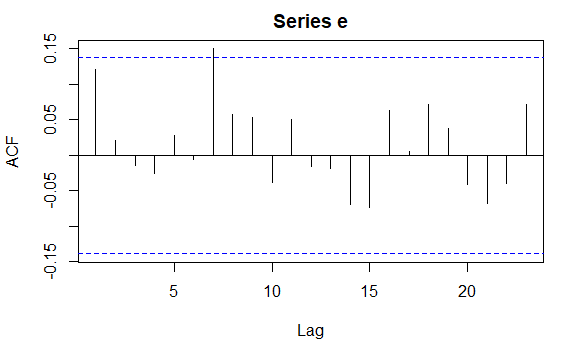

Comparando con el correlograma da perfecto. 0.12

En el grafico todas las barras deberian dar adentro, lo que refuerza que la autocorrelacion es 0, alguna se escapa pero esta bien.

Buena forma para verificar que es un ruido blanco.

# Simulación de una serie basada en un proceso MA(1)

$$X_{t} = \varepsilon _{t} + 0.8 \ \varepsilon_{t-1}$$

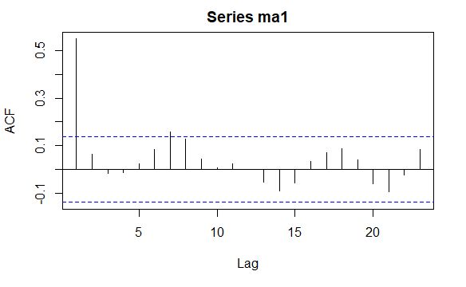

Examinamos la serie simulada

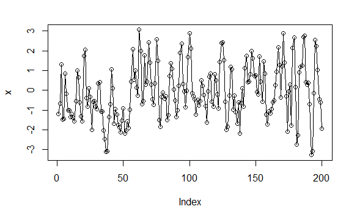

Se ve un poco mas de patron pero dificil verlo aca.

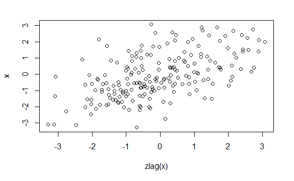

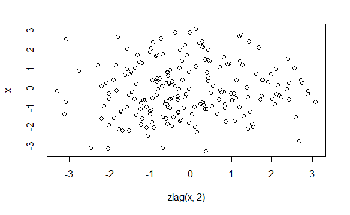

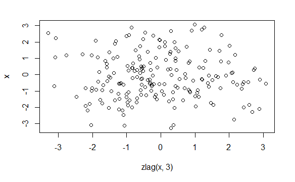

```r
plot(zlag(x), x)
plot(zlag(x,2), x)

plot(zlag(x,3), x)
```

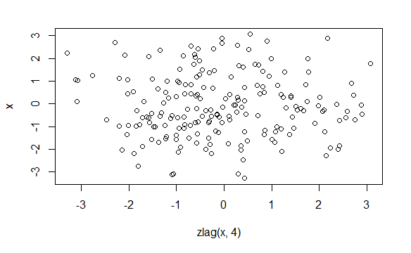

```r
plot(zlag(x,4), x)
```

- Primer corrleograma parece pendiente positiva, luego ya no se ve mas pendiente.
- Y vemos que el primer valor del acf[1] es 0.54 y luego se reducen, entonces vemos esa primera correlacion.

```r
fas$acf[1]
```

```
[1] 0.5497577
```

# Simulación de una serie basada en un proceso MA(2)

$$X_{t} = \varepsilon _{t} + 0.8 \ \varepsilon_{t-1} - 0.5 \ \varepsilon_{t-2}$$

A trabajar…

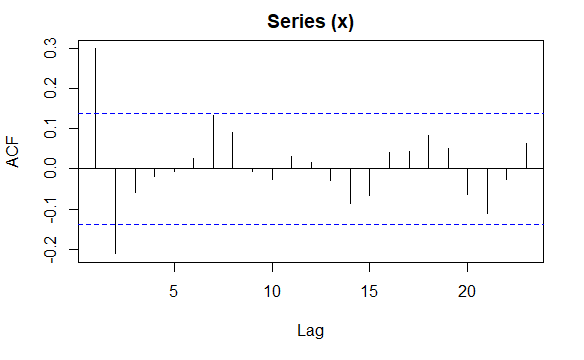

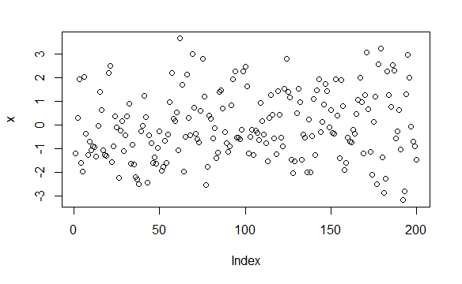

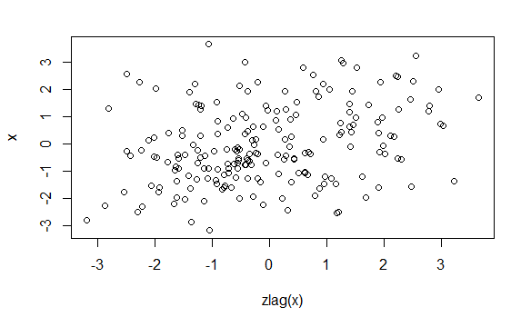

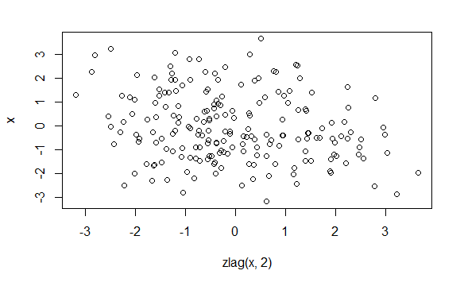

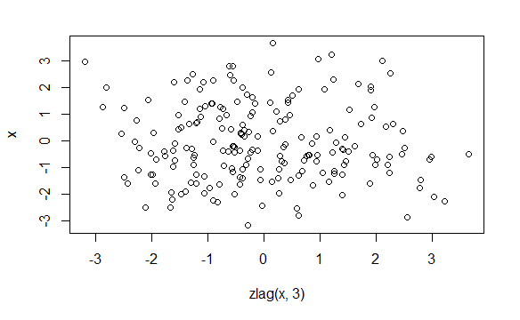

```r
plot(zlag(x), x)
plot(zlag(x,2), x)

plot(zlag(x,3), x)
```

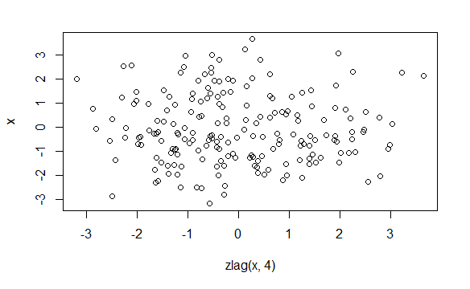

```r
plot(zlag(x,4), x)
```

```r
acf(x, plot=FALSE)$acf
```

```
, , 1

              [,1]
 [1,]  0.300424111
 [2,] -0.211647665
 [3,] -0.058321543
 [4,] -0.019039304
 [5,] -0.005641195
 [6,]  0.027365790
 [7,]  0.132729995
 [8,]  0.091882000
 [9,] -0.005102534
[10,] -0.024996056
[11,]  0.032095944
[12,]  0.015717698
[13,] -0.028178519
[14,] -0.084967886
[15,] -0.066850375
[16,]  0.041395456
[17,]  0.043522958
[18,]  0.084551934
[19,]  0.049969511
[20,] -0.063603818
[21,] -0.110642089
[22,] -0.025633093
[23,]  0.062693763
```

- Vemos que las correlaciones son 0.3 y -0.2, positiva y negativa.

¿Qué patrones esperamos observar en el caso de un proceso MA(q)?

Esperamos coeficientes de correlacion grandes hasta q.

# Tarea

Simular un proceso con la siguiente estructura:

$$X_{t} = 0.8 \ X_{t-1} + \varepsilon _{t}$$
Luego ver los graficos de la serie contra cada uno de los 4 primeros retardos y graficar la FAS muestral.